# 파이썬 특강 3주차

오늘은 정규표현식 및 파이썬에서의 PCA, 그리고 딥러닝에 관해 다루겠습니다.

1. 정규표현식

정규표현식은 사실, 암기의 영역이라고 보시면 됩니다.

사용법은 매우 간단하지만, 표현 자체가 정해져 있는 것이고 또 워낙 종류가 많다보니 암기를 필요로 합니다.

바꿔 말하면, 암기만 한다면 매우 간단한 것이 정규표현식입니다.

다음은 정규표현식에서 가장 많이 쓰는 것을 모아놓은 것입니다.

* : 바로 앞에 있는 문자, 하위 표현식, 대괄호로 묶인 문자들이 "0번이상" 나타납니다.

ex) a*b* 의 경우 aaaaaa, bbbbbb, aaaabbbb 등이 해당합니다.

+ : 바로 앞에 있는 문자, 하위 표현식, 대괄호로 묶인 문자들이 "1번이상" 나타납니다.

ex) a+b+ 의 경우 aaaaaab, aaabbbb, abbbb 등이 해당합니다.

[ ] : 대괄호 안에 있는 문자 중 하나가 나타납니다.

ex) [A-Z]* 의 경우 APPLE, BCD 등이 해당합니다.

{m,n} : 바로 앞에 있는 문자, 하위 표현식, 대괄호로 묶인 문자들이 m번이상 n번이하 나타납니다.

ex) a{2,3}b{2,3} 의 경우 aabbb, aabb 등이 해당합니다.

[^] : 대괄호 안에 있는 문자를 제외한 문자가 나타납니다.

ex) [^A-Z]* 의 경우 lowercase, hi 등이 해당합니다.

| : |로 분리된 문자, 문자열, 하위 표현식 중 하나가 나타납니다.

ex) b(a|i|e)d 의 경우 bad, bid, bed 등이 해당합니다.

. : 문자 하나(글자, 숫자, 기호, 공백 등)가 나타납니다.

ex) b.d 의 경우 bad, bzd, b$d, b d 등이 해당합니다.

^ : 바로 뒤에 있는 문자 혹은 하위 표현식이 문자열의 맨 앞에 나타납니다.

ex) ^a 의 경우 apple, asdf 등이 해당합니다.

\ : 특수 문자를 원래 의미대로 쓰게 하는 이스케이프 문자입니다.

$ : 정규 표현식 마지막에 종종 쓰이며, 바로 앞에 있는 문자 또는 하위 표현식이 문자열의 마지막이라는 뜻입니다.

ex) [A-Z]*$ 의 경우 ABC, BO 등이 해당합니다.

이를 응용해서 사용해보겠습니다.

이를 어떻게 사용하는 걸까요??

정규표현식은 우리가 원하는 조건에 부합하는 글만을 크롤링할 때 유용하게 쓰입니다.

다음을 보시죠.

```python
from bs4 import BeautifulSoup
import requests
import re
```

네이버 메인 페이지에서 한글로 구성된 단어를 모두 가져와보겠습니다.

조건 [가-힣]+가 뜻하는 것은 가-힣에 해당하는 문자가 1번이상 나타나는 것이므로 이는 한글로만 구성된 단어를 뜻합니다.

너무 많을 거 같으니까 앞에 10개 단어만 가져와보겠습니다.

```python
url = "https://www.naver.com"

response = requests.get(url)
html = response.text

soup = BeautifulSoup(html, 'html.parser')

korean = re.findall('[가-힣]+',html)

korean[0:10]
```

```
['네이버', '메인에서', '다양한', '정보와', '유용한', '컨텐츠를', '만나', '보세요', '네이버', '네이버']
```

이번에는 영어만 가져와보겠습니다.

```python
eng = re.findall('[A-z]+', html)

eng[0:10]
```

```
['doctype',
 'html',
 'html',
 'lang',
 'ko',
 'data',
 'dark',
 'false',
 'head',
 'meta']
```

이런식으로 정규표현식과 크롤링을 조합하여 원하는 글만을 웹페이지로부터 추출해낼 수 있는 것입니다.

1. PCA in Python

PCA에 대해서는 일요일 스터디 시간에 모두 배우셨을겁니다.

이번에는 이 PCA를 어떻게 파이썬에서 적용하는 지 알아보려고 합니다.

파이썬에서 일반적으로 PCA는 원하는 PC수를 지정하면서 이루어집니다.

PC수가 저장되어있는 PCA 객체를 만든 후 이를 이용해 fit하고 transform하는 구조라고 보시면 됩니다.

먼저, PCA는 sklearn 패키지의 decomposition모듈에서 속해있으므로 import 시켜보겠습니다.

```python
from sklearn.decomposition import PCA
```

```python
pca = PCA(n_components = 3) # 주성분이 3개가 되도록 하는 PCA 객체 생성
```

```python
#train_X, test_X는 각각 train데이터와 test데이터의 X변수 모음을 가리킴.
pca_train_completed = pca.fit_transform(train_X) # train의 X변수에 대해 fit하면서 transform도 동시에 수행
pca_test_completed = pca.transform(test_X) # test의 X변수에 대해 transform 수행(이 때, train에 대해 fit되어진 PCA이라는 것 염두)
```

이런 식으로 PCA가 이루어집니다. 내용에 비해 코드는 너무 쉽죠??!

참고로, PCA의 결과는 0을 평균으로한 값들로 변합니다 !

결과를 보고 당황할 필요 없다는 점을 미리 알려드립니다.

1. 딥러닝

사실 딥러닝은 다룰까말까 고민을 굉장히 많이 했는데, 그 이유는 이론적인 내용을 알지 못하면 코드를 봐도 이해가 힘들기 때문입니다.

그래서, 저번학기 패키지의 내용을 따라가면서 설명하기 위해 제가 풀었던 저번 기수 패키지 마지막주차 답안을 첨부해 스터디를 진행하겠습니다.

바로 진행하겠습니다.

# 21-01 주제분석 3주차 패키지

## 2. 딥러닝 기본

딥러닝 정말 간단히 해볼겁니다!

### 2.1 주어진 코드를 실행하고, 현재 신경망의 구조에 대해 간단히 설명해주세요.

```python
train = pd.read_csv('train.csv')
train_x = train.drop(['price'], axis = 1)
train_y = train.loc[:, ['price']]

val_x = train_x[train['transaction_year'] == 4]
val_y = train_y[train['transaction_year'] == 4]
train_tune_x = train_x[train['transaction_year'] < 4]
train_tune_y = train_y[train['transaction_year'] < 4]

CBE_encoder = CatBoostEncoder()
train_tune_cbe = CBE_encoder.fit_transform(train_tune_x[feature_list], train_tune_y)
val_cbe = CBE_encoder.transform(val_x[feature_list])
```

```python
import tensorflow as tf
import keras

from keras import models
from keras import layers
from keras.layers import Dense
from keras.optimizers import Adam
```

```python
def build_model():
  model = keras.Sequential([
    layers.Dense(256, activation='relu', input_shape=[len(train_tune_cbe.keys())]),
    layers.Dense(64, activation='relu'),
    layers.Dense(32, activation='relu'),
    layers.Dense(1)
  ])

  optimizer = tf.keras.optimizers.RMSprop(0.0001)

  model.compile(loss='mse',
                optimizer=optimizer,
                metrics=['mse'])
  return model
```

```python
model = build_model()
model.summary()
```

```
Model: "sequential"
_________________________________________________________________
Layer (type)                 Output Shape              Param #
=================================================================
dense (Dense)                (None, 256)               2304
_________________________________________________________________
dense_1 (Dense)              (None, 64)                16448
_________________________________________________________________
dense_2 (Dense)              (None, 32)                2080
_________________________________________________________________
dense_3 (Dense)              (None, 1)                 33
=================================================================
Total params: 20,865
Trainable params: 20,865
Non-trainable params: 0
_________________________________________________________________
```

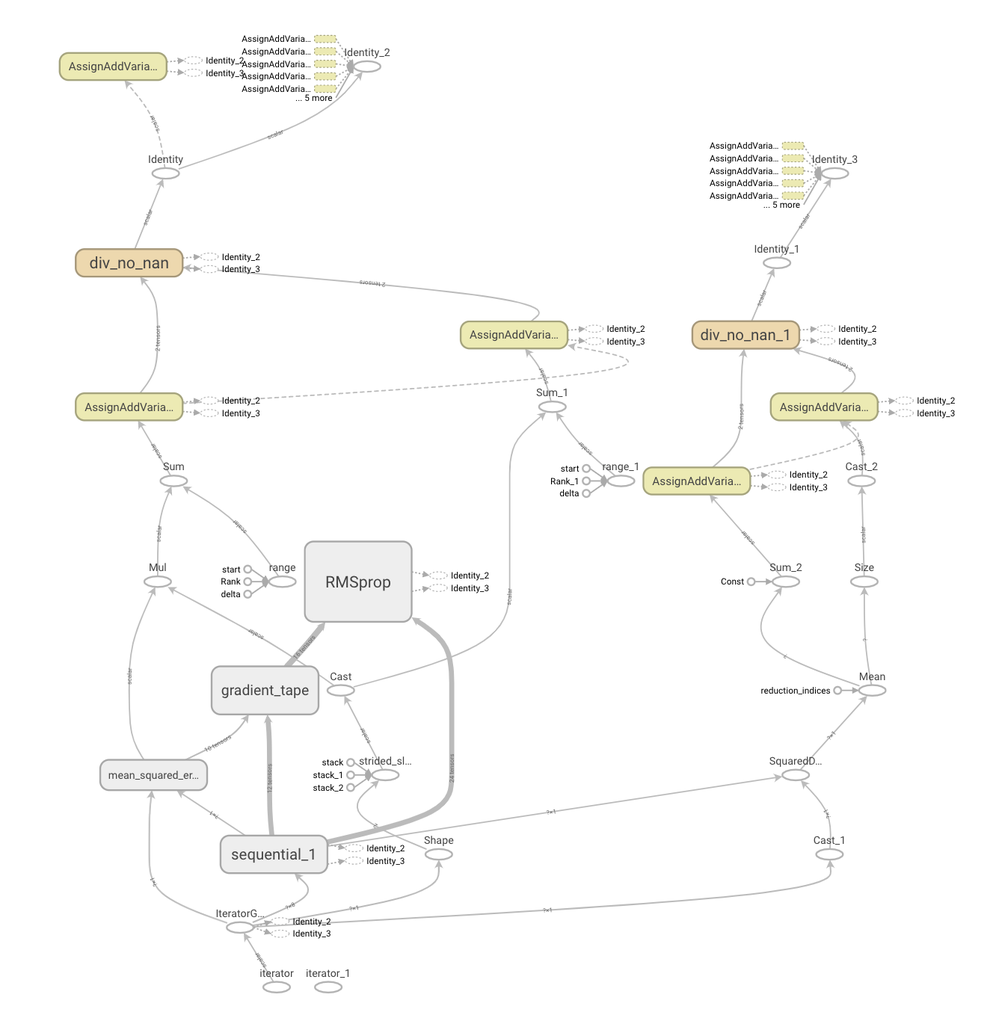

```python
display.Image("/Users/jaehyunlee/Desktop/Full_Model.png")
```

조금 더 자세히 보기 위해 우리가 model로 선언한 Sequential_1을 자세히 들여다보자.

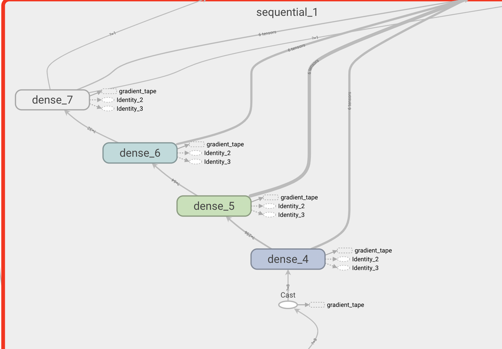

```python
display.Image("/Users/jaehyunlee/Desktop/Layer_Sequential.png")
```

이 구조를 살펴보면, 지금 우리는 우선 Dense Layer가 총 4개로 구성되어 있는 것을 알 수 있다.

첫 번째 Dense층에는 출력 뉴런의 수가 256개로 설정되어 있고, input shape가 입력되어 있다. (참고로, input shape는 첫 번째 층에 입력하면그 이후는 앞의 출력 뉴런의 수에 맞게 입력 출력 뉴런의 수가 정해지므로 이를 생략해도 된다.)

또한, activation은 활성화 함수를 일컫는데, 이는 지금 relu로 설정되어 있다. relu는 은닉층으로, 역전파를 통해 좋은 성능이 나오므로 마지막 층을 제외하고는 relu를 많이 사용한다.

두 번째 Dense층에는 64개의 출력 뉴런의 수가 설정되어 있다.

세 번째 Dense층에는 32개의 출력 뉴런의 수가 설정되어 있다.

마지막 Dense층에는 1개의 출력 뉴런의 수가 설정되는데, 보통 마지막 Dense에는 1로 설정한다.

참고로, Optimizer는 손실함수를 최소화하는 방향으로 가중치를 갱신하는 알고리즘을 일컫는데, 종류로는 SGD, RMSProp, Adam 등이 있고, 이 모델에서는 RMSProp을 사용한 것을 볼 수 있다.

### 2.2 training loss와 validation loss를 시각화하세요.

- 본인 컴에서 돌리면 꽤나 돌아갈수도 있어요. 주분과 함께하려면 패키지가 코랩으로 가거나, 주분이 코랩으로 가면 한번에 투 컴을 돌릴 수 있습니다.

```python
history = model.fit(train_tune_cbe, train_tune_y, epochs=300, validation_data = (val_cbe, val_y), batch_size = 512, callbacks = [tb_hist])
```

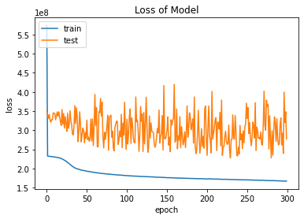

```python
plt.plot(history.history['loss'])
plt.plot(history.history['val_loss'])
plt.title('Loss of Model')
plt.ylabel('loss')
plt.xlabel('epoch')

plt.legend(['train','test'], loc = 'upper left')
plt.show()
```

### 2.3 어떤문제가 발생했는지 설명해주세요.

validation mse가 매우 크고, 또한 training loss가 validation보다 훨씬 작아진 것을 보면, 이것은 overfitting 되었다는 것을 의미한다.

그러므로 dropout을 증가시키는 등의 방법을 통해 과적합을 피하게끔 모델을 다듬어야 한다.

다듬는 과정은 정말 많은 요소가 첨가될 수 있다.

위에서 언급한 dropout이 될 수도 있고, 다른 Layer를 빼거나 추가하는 등의 레이어 구조를 변경해볼 수도 있다.

어떤 게 정답이라고 할 수 없고, 그 과정이 곧 튜닝과정이므로 밑에서 자세히 다뤄보겠다.

### 2.4 더 좋은 성능의 딥러닝 모델을 위해

- test set에 대해 딥러닝 모형의 성능을 평가하세요.
- dense 조절, batch_size 조절, regularization, dropout, batch normalization 등의 방법을 활용해 최고의 성능을 얻어보세요.
- 만약 성능의 향상이 어렵다면, 다양한 방법들을 시도하는 것을 목표로 해주세요!

```python
feature_list = list(train_x.columns)

CBE_encoder = CatBoostEncoder()
train_cbe = CBE_encoder.fit_transform(train_x[feature_list], train_y)
test_cbe = CBE_encoder.transform(test_x[feature_list])

yhat = model.predict(test_cbe)
```

```python
from sklearn.metrics import mean_squared_error
import math
```

```python
mse  = mean_squared_error(yhat, test_y)
rmse = math.sqrt(mse)
print("RMSE: %.3f"%rmse)
```

```
RMSE: 61098.271
```

위에 나타나 있는 모형에 대해서는 RMSE가 61098.271 이라는 것을 확인할 수 있다.

이제 이를 좀 줄여보자.

```python
def build_model():
  model = keras.Sequential([
    layers.Dense(256, activation='relu', input_shape=[len(train_tune_cbe.keys())]),
    layers.Dropout(0.3),
    layers.Dense(64, activation='relu'),
    layers.Dropout(0.3),
    layers.Dense(32, activation='relu'),
    layers.Dense(1)
  ])

  optimizer = tf.keras.optimizers.RMSprop(0.0001)

  model.compile(loss='mse',
                optimizer=optimizer,
                metrics=['mse'])
  return model

model = build_model()

#제출용이므로 verbose 0으로 설정해서 html 페이지 크기를 좀 줄이겠습니다.
history = model.fit(train_tune_cbe, train_tune_y, epochs=100, verbose = 0,validation_data = (val_cbe, val_y), batch_size = 32, callbacks = [tb_hist])
```

```python
yhat = model.predict(test_cbe)
mse  = mean_squared_error(yhat, test_y)
rmse = math.sqrt(mse)
print("RMSE: %.3f"%rmse)
```

```
RMSE: 39149.328
```

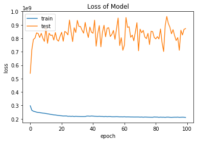

```python
plt.plot(history.history['loss'])
plt.plot(history.history['val_loss'])
plt.title('Loss of Model')
plt.ylabel('loss')
plt.xlabel('epoch')

plt.legend(['train','test'], loc = 'upper left')
plt.show()
```

rmse가 많이 줄어든 것을 볼 수 있다.

(미리 언급하자면, 이 값이 제가 수행한 값 중에서 가장 작은 RMSE를 보여주므로 이 친구만 시각화를 하겠습니다 그림은 뭔가 더 이상해보이지만, 단위가 다르다는 점 참고하면 될 듯 합니다)

이는 Dropout을 추가함으로써 오버피팅을 줄여주는 효과를 주었기 때문이다.

이렇게 단편적으로 하나하나 넣어보는 것은 비효율적이므로 GridSearch를 이용해 튜닝을 해보자.

또한, 레이어 구조를 조금 바꿔보자. Dropout값도 바꾸고, Dense Layer의 수도 좀 줄여보자.

```python
from itertools import product

def build_model():
  model = keras.Sequential([
    layers.Dense(256, activation='relu', input_shape=[len(train_tune_cbe.keys())]),
    layers.Dropout(0.2),
    layers.Dense(64, activation='relu'),
    layers.Dropout(0.2),
    layers.Dense(1)
  ])

  optimizer = tf.keras.optimizers.RMSprop(0.0001)

  model.compile(loss='mse',
                optimizer=optimizer,
                metrics=['mse'])
  return model

model = build_model()

batch_size = [50,100]
epochs = [10,50]
# 시간이 별로 없으므로 조금만 해보겠습니다. epoch도 작고, batch_size도 크게 해서 정확도를 낮추되 최대한 시간을 줄일 예정.
# 실제 튜닝에서는(저희 주제분석에서는) 이보다 훨씬 다양한 상황을 하이퍼 파라미터 튜닝을 진행했으나, 패키지는 시간 관계상 이런 흐름으로 한다 정도만 제시하

param_grid = list(product(*[batch_size, epochs]))

batch_list = []
epoch_list = []
rmse_list = []
for batch, epoch in param_grid :
    model.fit(train_tune_cbe, train_tune_y, verbose = 0, epochs=epoch, validation_data = (val_cbe, val_y), batch_size = batch)
    yhat = model.predict(test_cbe)
    mse  = mean_squared_error(yhat, test_y)
    rmse = math.sqrt(mse)

    batch_list.append(batch)
    epoch_list.append(epoch)
    rmse_list.append(rmse)

param_result = pd.DataFrame({'batch' : batch_list,
                            'epoch' : epoch_list,
                            'rmse' : rmse_list})
param_result
```

|  | batch | epoch | rmse |
| --- | --- | --- | --- |
| 0 | 50 | 10 | 60820.476267 |
| 1 | 50 | 50 | 57972.248330 |
| 2 | 100 | 10 | 55409.944803 |
| 3 | 100 | 50 | 55964.674731 |

rmse 값이 대체적으로 방금 전 모델보다 높은 것을 볼 수 있다. 이는 Dropout 값도 낮추었고, batch 사이즈도 조금 증가시켜서 그런 것이라 해석된다. 물론 한없이 증가시키거나 낮춘다고 무조건 모델이 좋은 방향으로 적합되는 것은 아니지만, 대체로 그런 경향이 있으므로 위와 같이 해석했다.

이번에는 Dense에 입력된 출력 뉴런의 수를 조절해보자. (256 -> 128, 64 -> 32)

원래 같았으면 파라미터도 다양하게 조정했을텐데, 현재 저희 주제분석에서도 딥러닝을 굉장히 다양하게 이용하므로(현재 이용하고 있으므로), 너무 하드하게 튜닝하는 것은 불필요한 작업이라 생각되어 간단하게 흐름만을 잡아가는 점 이해부탁드립니다.

```python
def build_model():
  model = keras.Sequential([
    layers.Dense(128, activation='relu', input_shape=[len(train_tune_cbe.keys())]),
    layers.Dropout(0.2),
    layers.Dense(32, activation='relu'),
    layers.Dropout(0.2),
    layers.Dense(1)
  ])

  optimizer = tf.keras.optimizers.RMSprop(0.0001)

  model.compile(loss='mse',
                optimizer=optimizer,
                metrics=['mse'])
  return model

model = build_model()


history = model.fit(train_tune_cbe, train_tune_y, verbose = 0,epochs=100, validation_data = (val_cbe, val_y), batch_size = 50)
```

```python
yhat = model.predict(test_cbe)
mse  = mean_squared_error(yhat, test_y)
rmse = math.sqrt(mse)
print("RMSE: %.3f"%rmse)
```

```
RMSE: 57330.094
```

이제 regularizer를 사용해보자.

```python
def build_model():
  model = keras.Sequential([
    layers.Dense(256, activation='relu',
                 kernel_regularizer=tf.keras.regularizers.L1(0.01),
        activity_regularizer=tf.keras.regularizers.L2(0.01)),
        layers.Dropout(0.2),
        layers.Dense(1)
  ])

  optimizer = tf.keras.optimizers.RMSprop(0.0001)

  model.compile(loss='mse',
                optimizer=optimizer,
                metrics=['mse'])
  return model

model = build_model()

history = model.fit(train_tune_cbe, train_tune_y, verbose = 0,epochs=100, validation_data = (val_cbe, val_y), batch_size = 50)
```

```python
yhat = model.predict(test_cbe)
mse  = mean_squared_error(yhat, test_y)
rmse = math.sqrt(mse)
print("RMSE: %.3f"%rmse)
```

```
RMSE: 58023.855
```

이번에는 batch normalization을 해보자.

```python
def build_model():
  model = keras.Sequential([
    layers.Dense(256, activation='relu'),
        layers.Dropout(0.2),
      layers.BatchNormalization(),
        layers.Dense(1)

  ])

  optimizer = tf.keras.optimizers.RMSprop(0.0001)

  model.compile(loss='mse',
                optimizer=optimizer,
                metrics=['mse'])
  return model


model = build_model()

history = model.fit(train_tune_cbe, train_tune_y, verbose = 0,epochs=100, validation_data = (val_cbe, val_y), batch_size = 50)
```

```python
yhat = model.predict(test_cbe)
mse  = mean_squared_error(yhat, test_y)
rmse = math.sqrt(mse)
print("RMSE: %.3f"%rmse)
```

```
RMSE: 50622.955
```